# Latihan MPDW

# Read Data

```r
data <- read.csv("D:\\IPB\\Statistika Sem 5\\MPDW (Deret Waktu)\\Data Jumlah Penumpang Transjakarta Harian Tahun 2023-2024.csv", sep=";")
head(data)
```

```
##   periode_data jumlah_penumpang_transjakarta tanggal X
## 1   01/01/2023                        363250       1
## 2   02/01/2023                        730984       2
## 3   03/01/2023                        783228       3
## 4   04/01/2023                        798449       4
## 5   05/01/2023                        807905       5
## 6   06/01/2023                        807617       6
```

# Data Utuh

```r
#hanya mengambil data pembagian tugas kelompok
utuh <- data[219:327,]
head(utuh)
```

```
##     periode_data jumlah_penumpang_transjakarta tanggal     X
## 219   07/08/2023                       1006666       7 HAPIS
## 220   08/08/2023                       1011406       8
## 221   09/08/2023                       1000208       9
## 222   10/08/2023                        991508      10
## 223   11/08/2023                        982905      11
## 224   12/08/2023                        676818      12
```

## Data Time Series

```r
utuh.ts <- utuh$jumlah_penumpang_transjakarta
utuh.ts
```

```
##   [1] 1006666 1011406 1000208  991508  982905  676818  597413 1008471 1011261
##  [10]  989925  535537  941749  625534  498446  433517  418970  416837  409463
##  [19]  408345  282422  246739  420126  422024  430748  417971 1015361  695963
##  [28]  617558 1026591 1014345 1014851 1007231 1032009  700670  621726 1065550
##  [37] 1078830 1074826 1070391 1064895  711037  605562 1080611 1094329 1101370
##  [46] 1090495 1081846  742942  611442 1100966 1105993 1109120  615710 1043002
##  [55]  730363  650239 1083284 1105891 1100992 1102279 1087623  725319  630556
##  [64] 1100382 1109216 1107503 1103250 1093067  727497  635855 1107316 1128713
##  [73] 1121625 1110376 1097821  721052  629687 1104758 1120393 1107625 1111359
##  [82] 1097914  748153  633768 1109764 1121596 1117922 1121811 1101969  735079
##  [91]  642921 1121028 1130181 1128956 1124007 1101730  748574  653803 1135364
## [100] 1146542 1132691 1131441 1126115  744568  654569 1146384 1149804 1171288
## [109] 1145343
```

## Plot Time Series

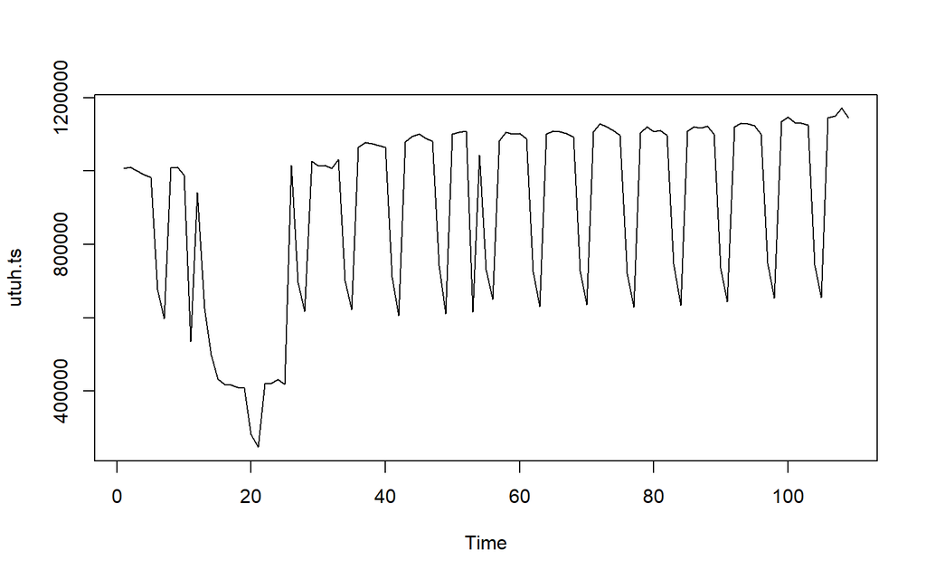

```r
ts.plot(utuh.ts)
```

Dari grafik terlihat bahwa data memiliki pola musiman

## Plot ACF

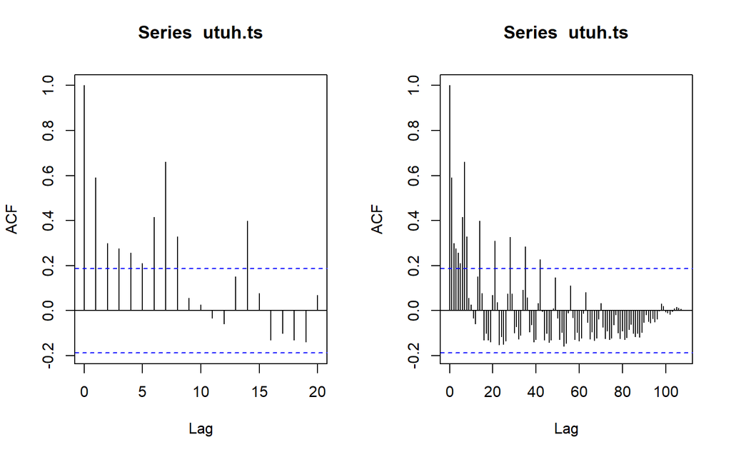

```r
par(mfrow=c(1,2))
acf(utuh.ts)
acf(utuh.ts, lag.max=109)
```

Dari plot ACF terlihat bahwa data memiliki pola musiman

## Plot PACF

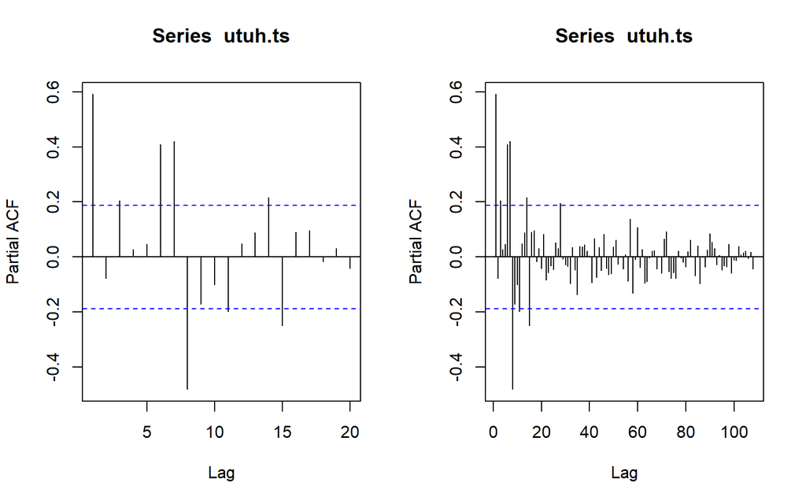

```r
par(mfrow=c(1,2))
pacf(utuh.ts)
pacf(utuh.ts, lag.max=109)
```

Dari plot PACF juga terlihat bahwa data memiliki pola musiman

## Uji ADF

```r
library(tseries)
adf.test(utuh.ts)
```

```
##
##  Augmented Dickey-Fuller Test
##
## data:  utuh.ts
## Dickey-Fuller = -4.1391, Lag order = 4, p-value = 0.01
## alternative hypothesis: stationary
```

$H_0$ : Data tidak stasioner dalam rataan

$H_1$ : Data stasioner dalam rataan

Berdasarkan uji ADF tersebut, didapat *p-value* sebesar 0.01 yang lebih kecil dari taraf nyata 5% sehingga tolak $H_0$ dan menandakan bahwa data stasioner dalam rataan.

## Plot Box-Cox

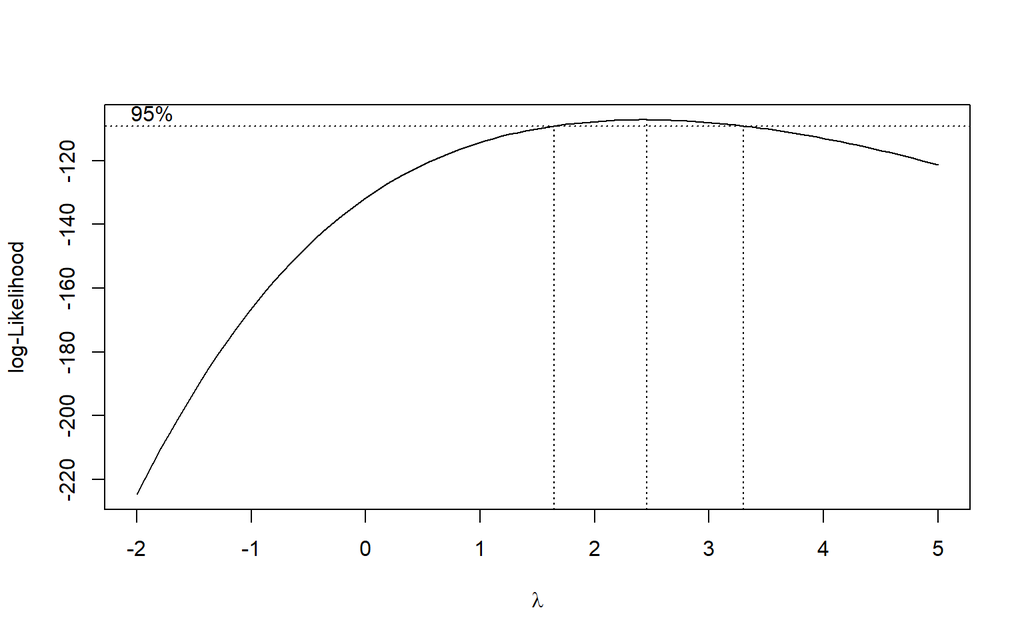

```r
library(MASS)
index <- 1:length(utuh.ts)
bc <- boxcox(utuh.ts ~ index, lambda=seq(-2, 5, 0.1))
```

```r
#Nilai Rounded Lambda
lambda <- bc$x[which.max(bc$y)]
lambda
```

```
## [1] 2.454545
```

```r
#SK
bc$x[bc$y > max(bc$y) - 1/2 * qchisq(.95,1)]
```

```
##  [1] 1.676768 1.747475 1.818182 1.888889 1.959596 2.030303 2.101010 2.171717
##  [9] 2.242424 2.313131 2.383838 2.454545 2.525253 2.595960 2.666667 2.737374
## [17] 2.808081 2.878788 2.949495 3.020202 3.090909 3.161616 3.232323
```

Dari plot Box-Cox gambar di atas menunjukkan nilai *rounded value* ($\lambda$) optimum sebesar **2,45** dan pada selang kepercayaan 95% nilai memiliki batas bawah **1,67** dan batas atas **3.23**. Selang tersebut tidak memuat nilai satu sehingga dapat dikatakan bahwa data bangkitan tidak stasioner dalam ragam.

# Partisi Data : Bagian 1

```r
partisi1 <- utuh.ts[1:55]
partisi1
```

```
##  [1] 1006666 1011406 1000208  991508  982905  676818  597413 1008471 1011261
## [10]  989925  535537  941749  625534  498446  433517  418970  416837  409463
## [19]  408345  282422  246739  420126  422024  430748  417971 1015361  695963
## [28]  617558 1026591 1014345 1014851 1007231 1032009  700670  621726 1065550
## [37] 1078830 1074826 1070391 1064895  711037  605562 1080611 1094329 1101370
## [46] 1090495 1081846  742942  611442 1100966 1105993 1109120  615710 1043002
## [55]  730363
```

## Plot Time Series Partisi 1

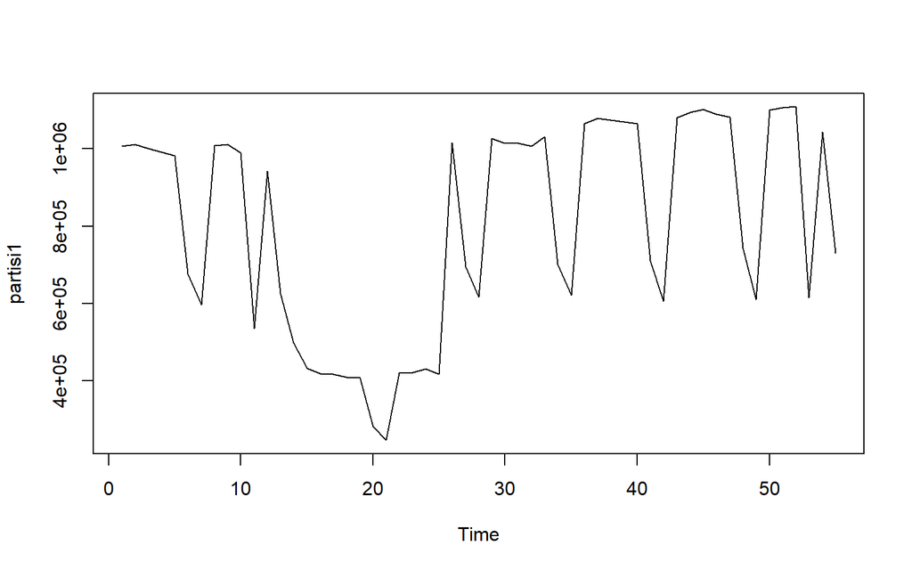

```r
ts.plot(partisi1)
```

Dari grafik terlihat bahwa data memiliki pola musiman

## Plot ACF Partisi 1

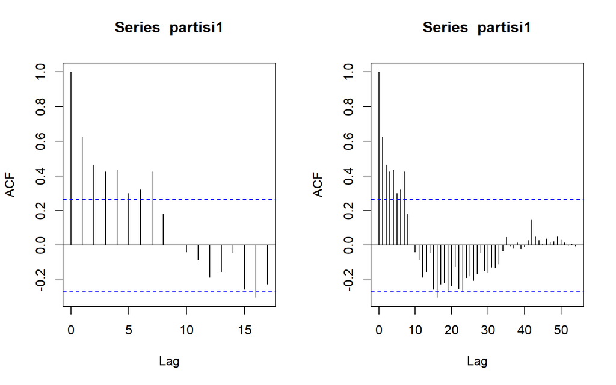

```r
par(mfrow=c(1,2))
acf(partisi1)
acf(partisi1, lag.max=55)
```

Dari plot ACF terlihat bahwa data memiliki pola musiman

## Plot PACF Partisi 1

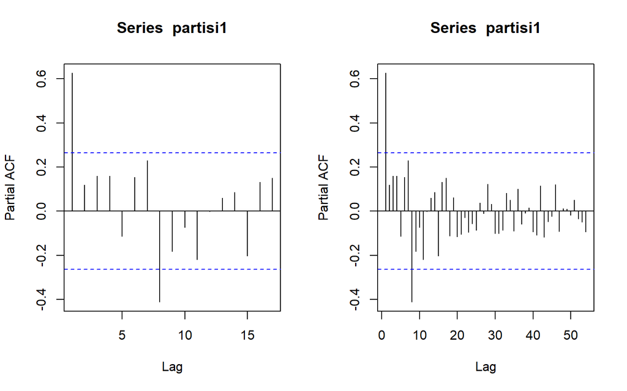

```r
par(mfrow=c(1,2))
pacf(partisi1)
pacf(partisi1, lag.max=55)
```

Dari plot PACF juga terlihat bahwa data memiliki pola musiman

## Uji ADF Partisi 1

```r
adf.test(partisi1)
```

```
##
##  Augmented Dickey-Fuller Test
##
## data:  partisi1
## Dickey-Fuller = -2.2447, Lag order = 3, p-value = 0.4759
## alternative hypothesis: stationary
```

$H_0$ : Data tidak stasioner dalam rataan

$H_1$ : Data stasioner dalam rataan

## Plot Box-Cox Partisi 1

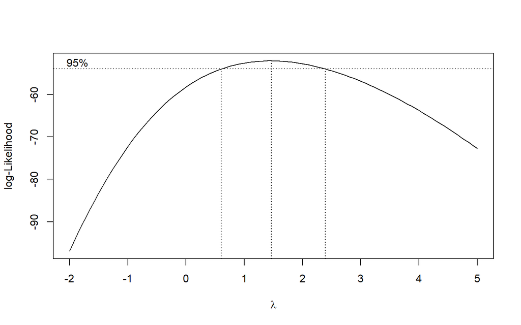

```r
index <- 1:length(partisi1)
bc <- boxcox(partisi1 ~ index, lambda=seq(-2, 5, 0.1))
```

```r
#Nilai Rounded Lambda
lambda <- bc$x[which.max(bc$y)]
lambda
```

```
## [1] 1.464646
```

```r
#SK
bc$x[bc$y > max(bc$y) - 1/2 * qchisq(.95,1)]
```

```
##  [1] 0.6161616 0.6868687 0.7575758 0.8282828 0.8989899 0.9696970 1.0404040
##  [8] 1.1111111 1.1818182 1.2525253 1.3232323 1.3939394 1.4646465 1.5353535
## [15] 1.6060606 1.6767677 1.7474747 1.8181818 1.8888889 1.9595960 2.0303030
## [22] 2.1010101 2.1717172 2.2424242 2.3131313 2.3838384
```

Dari plot Box Cox gambar di atas menunjukkan nilai *rounded value* ($\lambda$) optimum sebesar **1,46** dan pada selang kepercayaan 95% nilai memiliki batas bawah **0.61** dan batas atas **2,38**. Selang tersebut memuat nilai satu sehingga dapat dikatakan bahwa data bangkitan stasioner dalam ragam.

# Partisi Data : Bagian 2

```r
partisi2 <- utuh.ts[56:109]
partisi2
```

```
##  [1]  650239 1083284 1105891 1100992 1102279 1087623  725319  630556 1100382
## [10] 1109216 1107503 1103250 1093067  727497  635855 1107316 1128713 1121625
## [19] 1110376 1097821  721052  629687 1104758 1120393 1107625 1111359 1097914
## [28]  748153  633768 1109764 1121596 1117922 1121811 1101969  735079  642921
## [37] 1121028 1130181 1128956 1124007 1101730  748574  653803 1135364 1146542
## [46] 1132691 1131441 1126115  744568  654569 1146384 1149804 1171288 1145343
```

## Plot Time Series Partisi 2

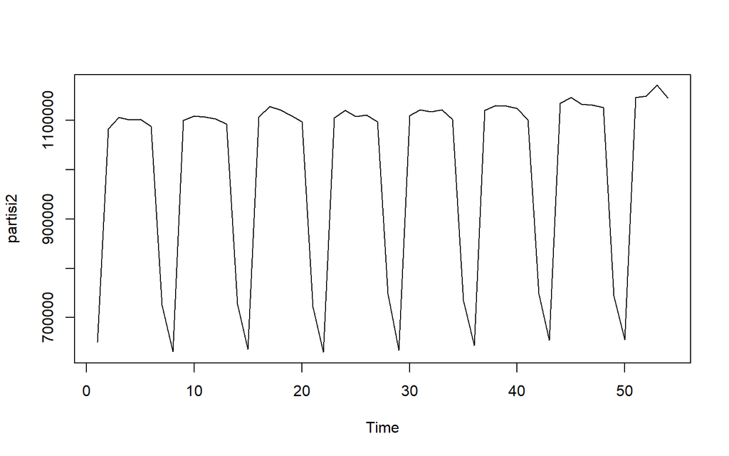

```r
ts.plot(partisi2)
```

Dari grafik terlihat bahwa data memiliki pola musiman

## Plot ACF Partisi 2

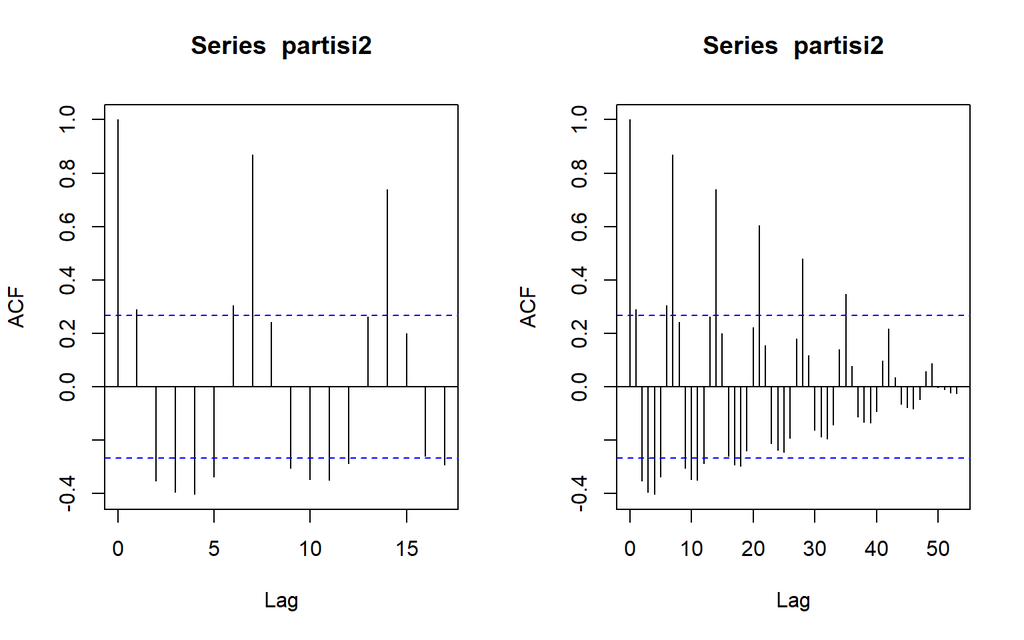

```r
par(mfrow=c(1,2))
acf(partisi2)
acf(partisi2, lag.max=55)
```

Dari plot ACF terlihat bahwa data memiliki pola musiman

## Plot PACF Partisi 2

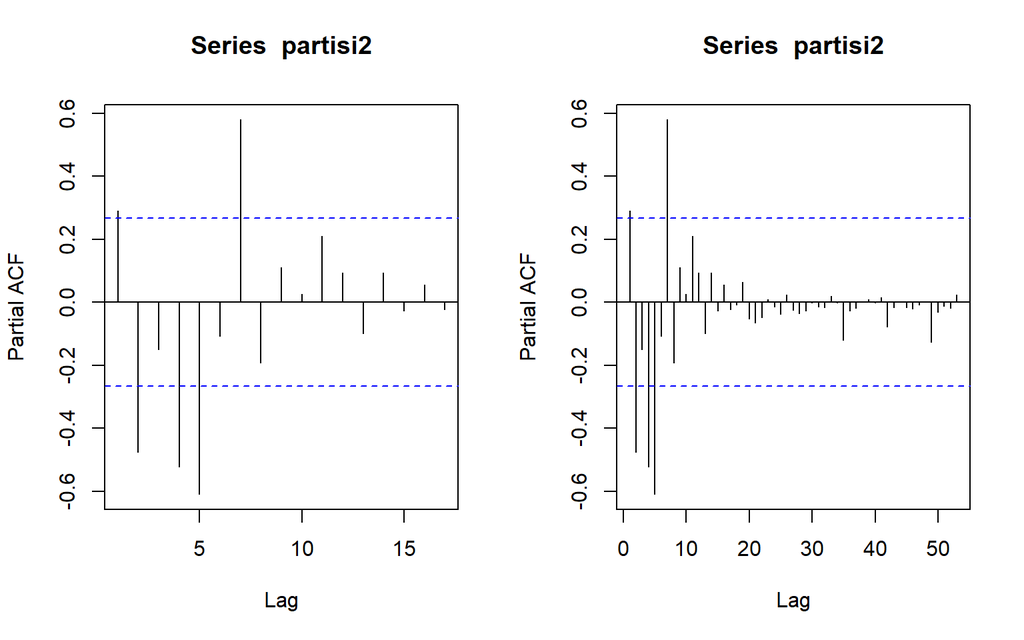

```r
par(mfrow=c(1,2))
pacf(partisi2)
pacf(partisi2, lag.max=55)
```

## Uji ADF Partisi 2

```r
adf.test(partisi2)
```

```
##
##  Augmented Dickey-Fuller Test
##
## data:  partisi2
## Dickey-Fuller = -8.6535, Lag order = 3, p-value = 0.01
## alternative hypothesis: stationary
```

$H_0$ : Data tidak stasioner dalam rataan

$H_1$ : Data stasioner dalam rataan

Dari uji ADF tersebut, didapat *p-value* sebesar 0.01 yang lebih kecil dari taraf nyata 5% sehingga tolak $H_0$ dan menandakan bahwa data stasioner dalam rataan.

## Plot Box-Cox Partisi 2

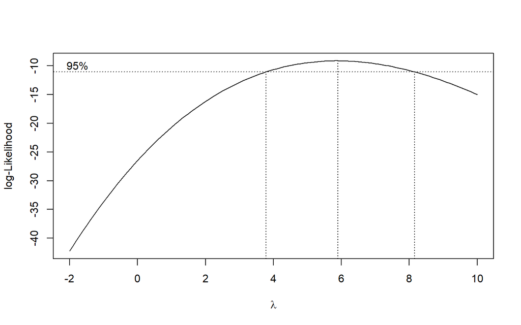

```r
index <- 1:length(partisi2)
bc <- boxcox(partisi2 ~ index, lambda=seq(-2, 10, 0.1))
```

```r
#Nilai Rounded Lambda
lambda <- bc$x[which.max(bc$y)]
lambda
```

```
## [1] 5.9
```

```r
#SK
bc$x[bc$y > max(bc$y) - 1/2 * qchisq(.95,1)]
```

```
##  [1] 3.8 3.9 4.0 4.1 4.2 4.3 4.4 4.5 4.6 4.7 4.8 4.9 5.0 5.1 5.2 5.3 5.4 5.5 5.6
## [20] 5.7 5.8 5.9 6.0 6.1 6.2 6.3 6.4 6.5 6.6 6.7 6.8 6.9 7.0 7.1 7.2 7.3 7.4 7.5
## [39] 7.6 7.7 7.8 7.9 8.0 8.1
```

Dari plot Box Cox gambar di atas menunjukkan nilai *rounded value* ($\lambda$) optimum sebesar **5,9** dan pada selang kepercayaan 95% nilai memiliki batas bawah **3,8** dan batas atas **8,1**. Selang tersebut tidak memuat nilai satu sehingga dapat dikatakan bahwa data bangkitan tidak stasioner dalam ragam.